# Влияние типа прихода клиента на LTV

Ihar Alishkevich

2022-06-13

## Введение

Проводится исследование на основе реальных данных образовательной школы **Itgenio**. Используются реальные данные *LTV*, полученные путем когортного анализа[^1] и разбитые на 3 группы по типу прихода:

1. таргетинговая кампания[^2];
2. реферал[^3];
3. остальные.

В связи с когортным отображением, из чего следует большое число колонок, данные удобнее просмотреть в браузере[^4].

```r
ltv_target_df <- read_sheet(
  "https://docs.google.com/spreadsheets/d/1LTSw4nZUKFMoh0HJ88Gs36aJQaaxq4GkPCu7drYTj4E/edit?usp=sharing",
  sheet = "LTV target"
)
```

```
## v Reading from "Влияние типа прихода клиента на LTV".
```

```
## v Range ''LTV target''.
```

```r
ltv_referral_df <- read_sheet(
  "https://docs.google.com/spreadsheets/d/1LTSw4nZUKFMoh0HJ88Gs36aJQaaxq4GkPCu7drYTj4E/edit?usp=sharing",
  sheet = "LTV referral"
)
```

```
## v Reading from "Влияние типа прихода клиента на LTV".
```

```
## v Range ''LTV referral''.
```

```r
ltv_unknown_df <- read_sheet(
  "https://docs.google.com/spreadsheets/d/1LTSw4nZUKFMoh0HJ88Gs36aJQaaxq4GkPCu7drYTj4E/edit?usp=sharing",
  sheet = "LTV unknown"
)
```

```
## v Reading from "Влияние типа прихода клиента на LTV".
```

```
## v Range ''LTV unknown''.
```

```r
# Если не удается считать данные через google, можно воспользоваться привычной загрузкой csv из github. Например:
# ltv_unknown_df <- read.csv("https://raw.githubusercontent.com/Delictum/Rmarkdown/main/%D0%92%D0%BB%D0%B8%D1%8F%D0%BD%D0%B8%D0%B5%20%D1%82%D0%B8%D0%BF%D0%B0%20%D0%BF%D1%80%D0%B8%D1%85%D0%BE%D0%B4%D0%B0%20%D0%BA%D0%BB%D0%B8%D0%B5%D0%BD%D1%82%D0%B0%20%D0%BD%D0%B0%20LTV%20-%20LTV%20referral.csv")
```

Данные содержат наблюдения за `29` месяцев. Первое значение каждой строки (столбец `index`) отображают, когда клиент впервые завершил оплаченное занятие. На основе этого попадает в соответствующую когорту.

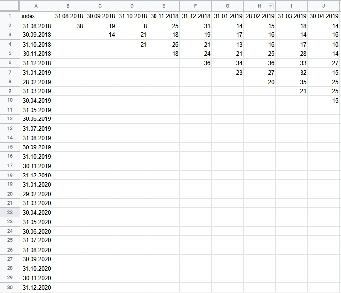

Остальные столбцы отображают LTV когорт в данном месяце. Для примера когорта клиентов от `2018-10-31` на дату `31.10.2018` принесли прибыли в `21` условных единиц. Используемая версия R: `4.1.2`.

## Гипотеза

Выдвигается предположение, что клиенты, пришедшие благодаря усилиям таргетинговых кампаний, приносят наибольший LTV в сфере образования.

## Вычисления

### Предварительная обработка данных

Для примера возьмем данные за дату `2018-12-31`.

```r
num_row = 5

ltv_u_df <- t(ltv_unknown_df[num_row, -1])
ltv_r_df <- t(ltv_referral_df[num_row, -1])
ltv_t_df <- t(ltv_target_df[num_row, -1])
head(ltv_u_df)
```

```
##            [,1]
## 31.08.2018   NA
## 30.09.2018   NA
## 31.10.2018   NA
## 30.11.2018   NA
## 31.12.2018   21
## 31.01.2019   24
```

И объеденим в единый `data.frame`, предварительно избавившись от пустых значений. В том числе добавим столбец с типом `factor` для идентификации полученного LTV по типу прихода клиента.

```r
u_df <- data.frame(
  ltv = c(ltv_u_df[!is.na(ltv_u_df[,1]),], use.names = F),
  type = "unknown",
  date = names(c(ltv_u_df[!is.na(ltv_u_df[,1]),], use.names = T))
)
t_df <- data.frame(
  ltv = c(ltv_t_df[!is.na(ltv_t_df[,1]),], use.names = F),
  type = "target",
  date = names(c(ltv_t_df[!is.na(ltv_t_df[,1]),], use.names = T))
)
r_df <- data.frame(
  ltv = c(ltv_r_df[!is.na(ltv_r_df[,1]),], use.names = F),
  type = "referral",
  date = names(c(ltv_r_df[!is.na(ltv_r_df[,1]),], use.names = T))
)
res_df <- rbind(u_df, t_df, r_df)
res_df$type <- as.factor(res_df$type)
str(res_df)
```

```
## 'data.frame':    75 obs. of  3 variables:
##  $ ltv : num  21 24 19 20 18 13 10 7 6 9 ...
##  $ type: Factor w/ 3 levels "referral","target",..: 3 3 3 3 3 3 3 3 3 3 ...
##  $ date: chr  "31.12.2018" "31.01.2019" "28.02.2019" "31.03.2019" ...
```

### Осмотр данных

Взглянем на несколько покзателей из каждой группы:

```r
res_df %>%
  group_by(type) %>%
  summarise(
    count_type = n(),
    mean_ltv = mean(ltv, na.rm = TRUE),
    median_ltv = median(ltv, na.rm = TRUE),
    sd_ltv = sd(ltv, na.rm = TRUE)
  )
```

```
## # A tibble: 3 x 5
##   type     count_type mean_ltv median_ltv sd_ltv
##   <fct>         <int>    <dbl>      <dbl>  <dbl>
## 1 referral         25    11.2          12   9.94
## 2 target           25    11.1           6  12.1
## 3 unknown          25     9.64          7   5.94
```

Для полноты картины провизуализируем данные:

```r
res_df %>%
  ggvis(~date, ~ltv, stroke = ~type) %>%
  group_by(type) %>%
  layer_paths() %>%
  layer_points(fill := "white") %>%
  add_axis("x", title = "", properties = axis_props(
    axis = list(stroke = "red", strokeWidth = 3),
    grid = list(stroke = "lightblue"),
    ticks = list(stroke = "blue", strokeWidth = 1),
    labels = list(angle = 45, align = "left", fontSize = 12)
  )) %>%
  add_axis("y", title = "LTV") %>%
  add_legend("stroke", title = "Тип прихода",
    properties = legend_props(
      title = list(fontSize = 16),
      labels = list(fontSize = 12, fill = "#00F"),
      gradient = list(stroke = "red", strokeWidth = 2),
      legend = list(x = 500, y = 50)
    )
  )
```

[output not shown]

А также через ящик с усами:

```r
res_df %>%
  ggvis(~type, ~ltv) %>%
  layer_boxplots() %>%
  add_axis("x", title = "Тип прихода клиента") %>%
  add_axis("y", title = "LTV")
```

[output not shown]

### Проверка гипотезы

Проверим есть ли статистически значимая разница при помощи дисперсионного анализа:

```r
anova_one_way <- aov(ltv ~ type, data = res_df)
summary(anova_one_way)
```

```
##             Df Sum Sq Mean Sq F value Pr(>F)
## type         2     40   19.85   0.213  0.809
## Residuals   72   6711   93.21
```

Как видно из результата, p-value значительно выше 0.05. Исследуем оставшиеся когорты. Если значений для одной из когорт не окажется, пропустим их, выведя соотвествующее сообщение. Применив дисперсионный анализ и если найдена статистическая разница, найдем где она находится при помощи критерия Тьюки [^5] (и выведем графики для наглядности):

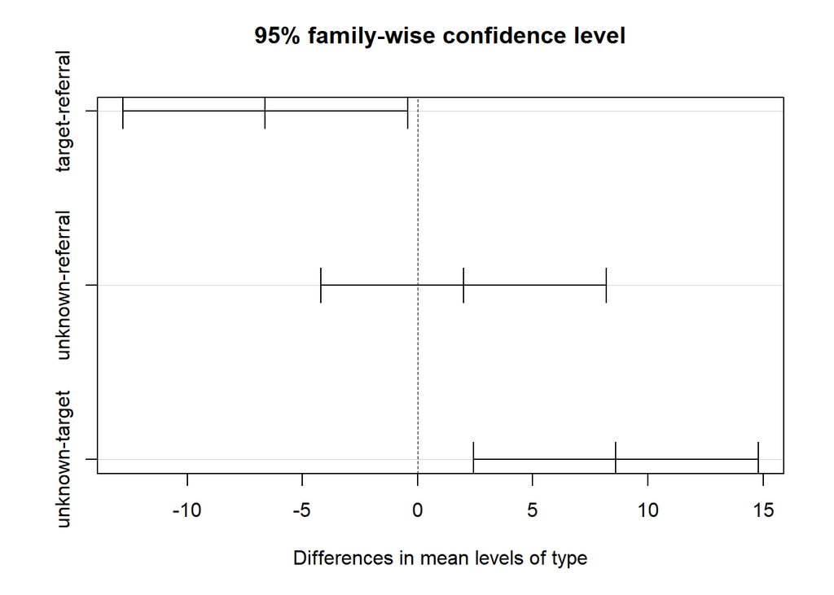

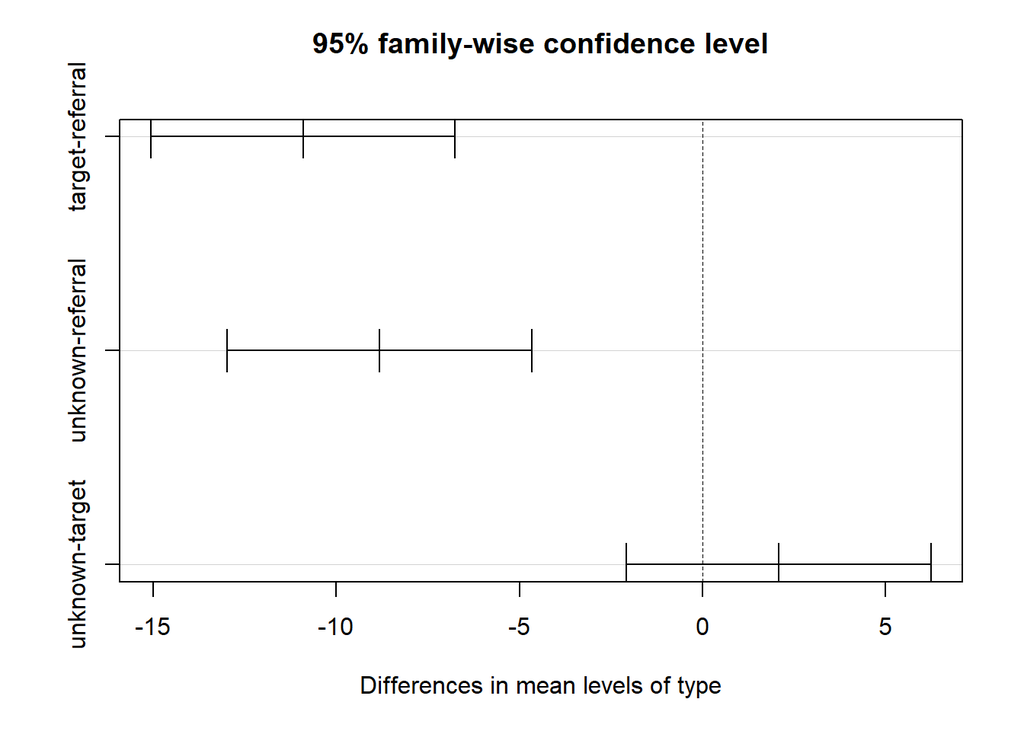

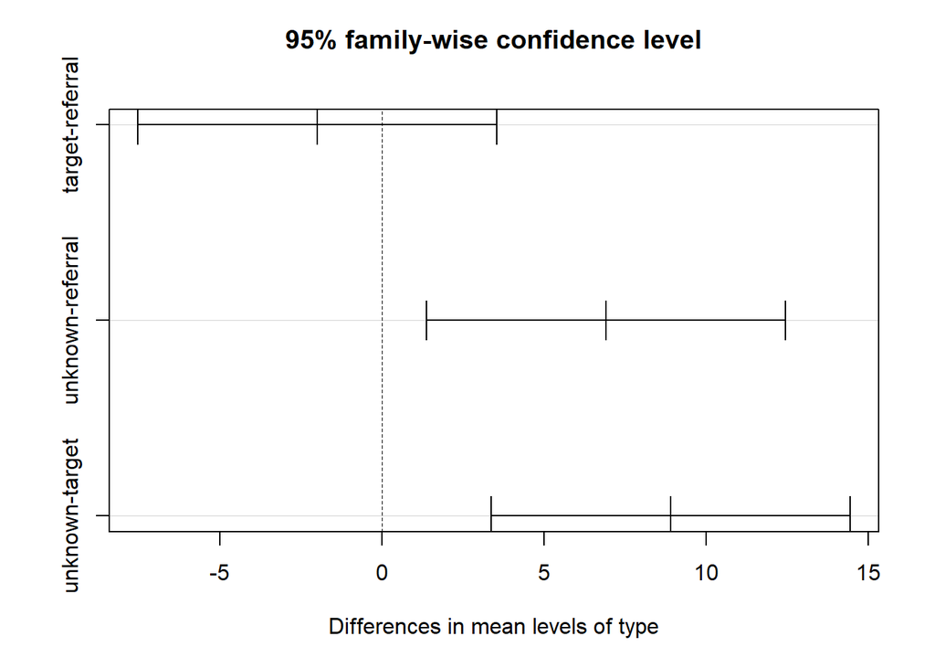

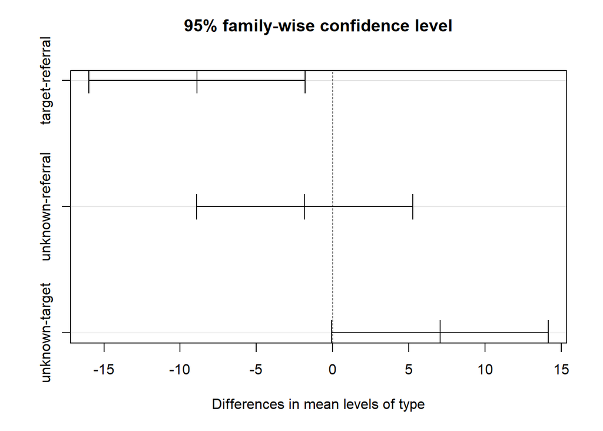

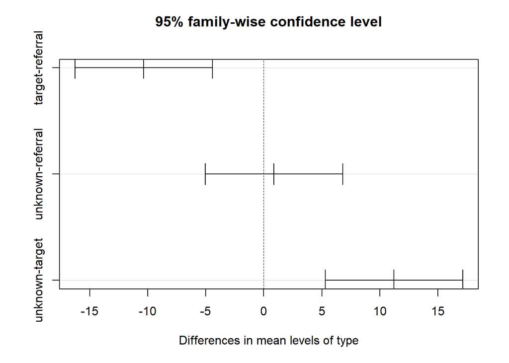

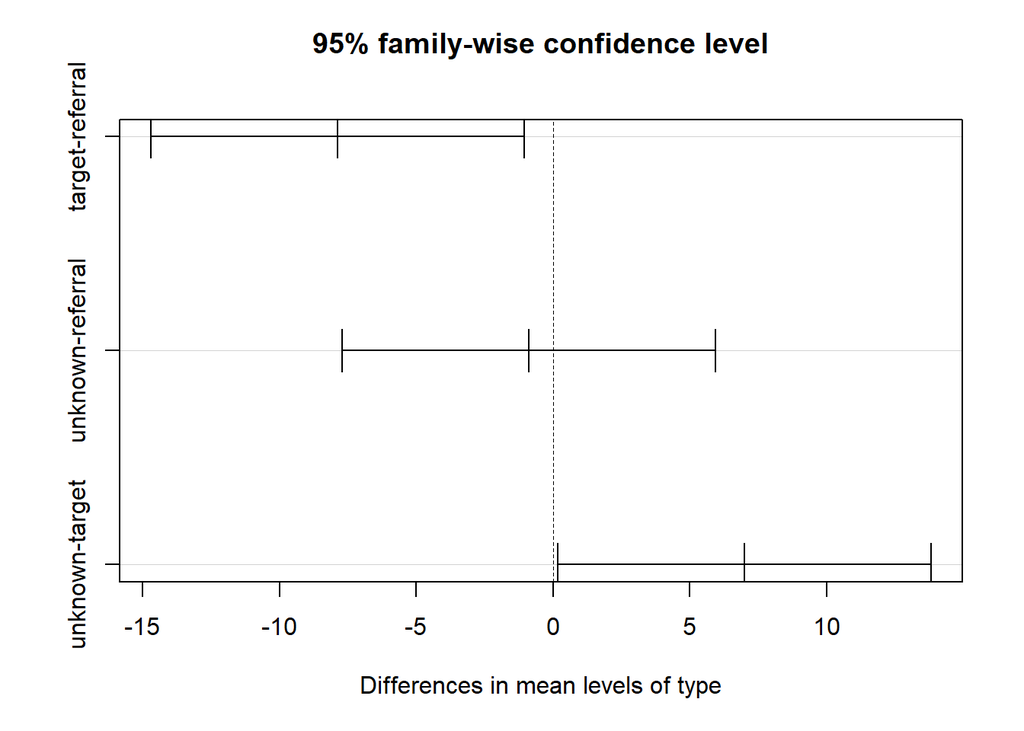

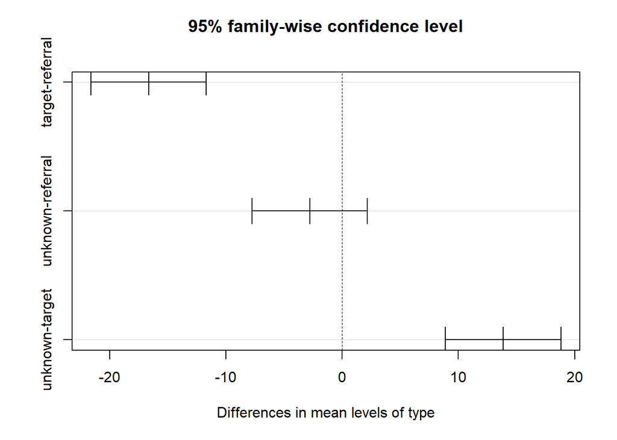

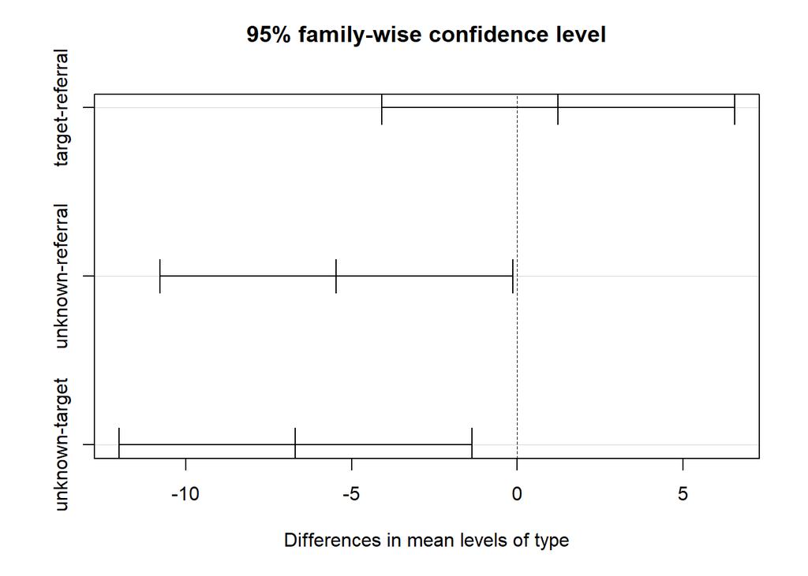

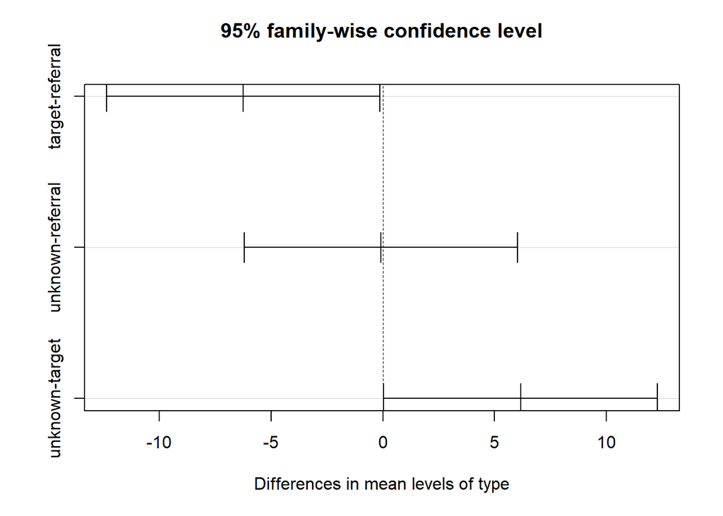

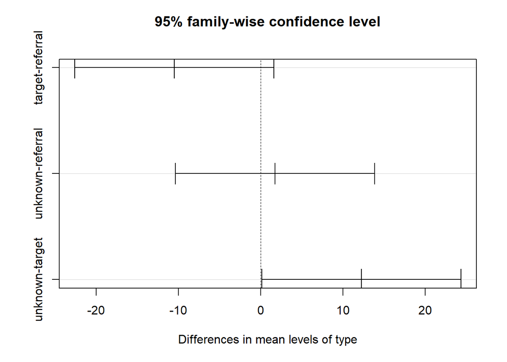

```
## [[1]]
## [1] "31.08.2018"          "Недостаточно данных"
##
## [[2]]
## [1] "30.09.2018"          "Недостаточно данных"
##
## [[3]]
## [1] "31.10.2018"          "Недостаточно данных"
##
## [[4]]
## [1] "30.11.2018"        "0.808662874783857" "aov > 0.05"
##
## [[5]]
## [1] "31.12.2018"         "0.0688831097983599" "aov > 0.05"
##
## [[6]]
## [[6]][[1]]
## [1] "31.01.2019"
##
## [[6]]$type
##                       diff        lwr        upr       p adj
## target-referral  -6.608696 -12.792778 -0.4246134 0.033508519
## unknown-referral  2.000000  -4.184082  8.1840822 0.719323151
## unknown-target    8.608696   2.424613 14.7927779 0.003925894
##
##
## [[7]]
## [[7]][[1]]
## [1] "28.02.2019"
##
## [[7]]$type
##                        diff        lwr       upr        p adj
## target-referral  -10.909091 -15.067577 -6.750605 9.853431e-08
## unknown-referral  -8.818182 -12.976668 -4.659696 1.029589e-05
## unknown-target     2.090909  -2.067577  6.249395 4.535636e-01
##
##
## [[8]]
## [1] "31.03.2019"        "0.838012215785422" "aov > 0.05"
##
```

[output cut: 105 more lines]

```
##
## [[23]]
## [1] "30.06.2020"        "0.191562049512868" "aov > 0.05"
##
## [[24]]
## [1] "31.07.2020"        "0.956892862186442" "aov > 0.05"
##
## [[25]]
## [1] "31.08.2020"        "0.991031447539367" "aov > 0.05"
##
## [[26]]
## [1] "30.09.2020"        "0.484728486989564" "aov > 0.05"
##
## [[27]]
## [1] "31.10.2020"        "0.939097085608934" "aov > 0.05"
```

```r
num_row = 5

get_ltv_df <- function(num_row) {
  current_cohort <- names(ltv_unknown_df[, num_row])
  ltv_u_df <- t(ltv_unknown_df[num_row, -1])
  ltv_r_df <- t(ltv_referral_df[num_row, -1])
  ltv_t_df <- t(ltv_target_df[num_row, -1])

  u_df <- data.frame(
    ltv = c(ltv_u_df[!is.na(ltv_u_df[,1]),], use.names = F),
    type = "unknown",
    date = names(c(ltv_u_df[!is.na(ltv_u_df[,1]),], use.names = T))
  )
  t_df <- data.frame(
    ltv = c(ltv_t_df[!is.na(ltv_t_df[,1]),], use.names = F),
    type = "target",
    date = names(c(ltv_t_df[!is.na(ltv_t_df[,1]),], use.names = T))
  )
  r_df <- data.frame(
    ltv = c(ltv_r_df[!is.na(ltv_r_df[,1]),], use.names = F),
    type = "referral",
    date = names(c(ltv_r_df[!is.na(ltv_r_df[,1]),], use.names = T))
  )

  if ((u_df$ltv == rep(0, nrow(u_df))) | (t_df$ltv == rep(0, nrow(t_df))) | (r_df$ltv == rep(0, nrow(r_df)))) {
    return(c(current_cohort, "Недостаточно данных"))
  }

  res_df <- rbind(u_df, t_df, r_df)
  res_df$type <- as.factor(res_df$type)

  anova_one_way <- aov(ltv ~ type, data = res_df)
  p <- summary(anova_one_way)[[1]][["Pr(>F)"]][1]
  if (p > 0.05) {
    return(c(current_cohort, p, "aov > 0.05"))
  }

  tukey_result <- TukeyHSD(anova_one_way)

  # Согласно документации:
  # There are print and plot methods for class "TukeyHSD". The plot method does not accept xlab, ylab or main arguments and creates its own values for each plot.
  base::plot(tukey_result)
  return(c(current_cohort, tukey_result))
}

lapply(c(2:(ncol(ltv_unknown_df)-2)), FUN = function(x) get_ltv_df(x))
```

## Выводы

Согласно полученным данным можно сделать вывод, что присутствует некая *третья* переменная, которая определяет результат. Тем не менее из полученных данных часто проскакивает зависимость между неизвестным типом прихода к остальным как самая незначимая. Что это может быть за третья переменная? Вероятно она может быть связана непосредственно с проведенной таргетинговой кампанией в тот период времени. Но точного ответа нет, поэтому нельзя заявить, что **клиенты, пришедшие благодаря усилиям таргетинговых кампаний, приносят наибольший LTV**.